# Relatorio Final - Corrigido 1

Daniel Barbosa

Análise Estatística

Author

Lucas Castanheira e José Guilherme - FitoData

Published

September 27, 2024

# 1. Contagem de Plantas Atacadas (Incidência)

Para avaliar a incidência de plantas com danos no cartucho do milho, consideramos a porcentagem de plantas atacadas (número de plantas atacadas dividido por 25).

## 1.1. Visualização dos dados

Na figura abaixo está representada o efeito das taxas de aplicação e adjuvantes sobre a incidência ao longo do tempo.

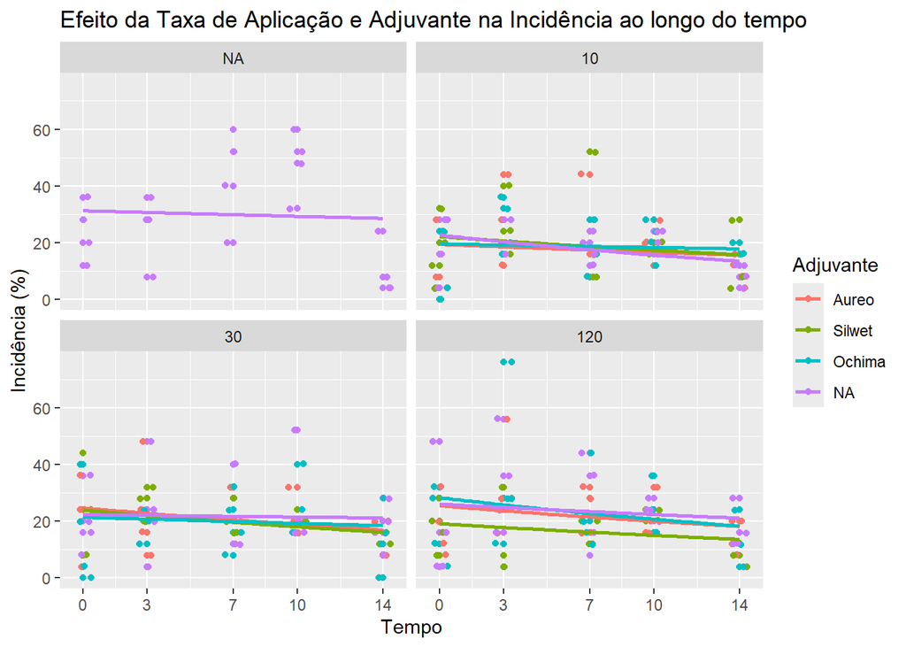

## 1.2. Análise Descritiva

### Geral

**Incidência - Geral**

**Porcentagem de plantas atacadas**

| **Tratamento** | **Adjuvante** | **Taxa** | **Média (%)** | **Desvio** |
| --- | --- | --- | --- | --- |
| 1 | NA | NA | 30.0 | 18.005847 |
| 2 | Aureo | 10 | 17.6 | 11.851715 |
| 3 | Silwet | 10 | 19.0 | 12.234550 |
| 4 | Ochima | 10 | 18.8 | 9.720299 |
| 5 | NA | 10 | 18.0 | 7.732365 |
| 6 | Aureo | 30 | 20.8 | 11.057743 |
| 7 | Silwet | 30 | 20.0 | 8.510056 |
| 8 | Ochima | 30 | 20.0 | 13.042441 |
| 9 | NA | 30 | 21.8 | 13.008499 |
| 10 | Aureo | 120 | 21.8 | 11.124179 |
| 11 | Silwet | 120 | 16.4 | 7.989467 |
| 12 | Ochima | 120 | 23.2 | 16.240301 |
| 13 | NA | 120 | 23.6 | 14.387129 |

### 0DAA

**Incidência - 0DAA**

**Porcentagem de plantas atacadas**

| **Tratamento** | **Adjuvante** | **Taxa** | **Média (%)** | **Desvio** |
| --- | --- | --- | --- | --- |
| 1 | NA | NA | 24 | 10.33 |
| 2 | Aureo | 10 | 11 | 11.49 |
| 3 | Silwet | 10 | 17 | 11.94 |
| 4 | Ochima | 10 | 13 | 12.81 |
| 5 | NA | 10 | 19 | 11.49 |
| 6 | Aureo | 30 | 22 | 13.27 |
| 7 | Silwet | 30 | 21 | 17.09 |
| 8 | Ochima | 30 | 16 | 18.18 |
| 9 | NA | 30 | 20 | 11.78 |
| 10 | Aureo | 120 | 18 | 10.58 |
| 11 | Silwet | 120 | 18 | 8.33 |
| 12 | Ochima | 120 | 19 | 13.22 |
| 13 | NA | 120 | 18 | 20.78 |

### 3DAA

**Incidência - 3DAA**

**Porcentagem de plantas atacadas**

| **Tratamento** | **Adjuvante** | **Taxa** | **Média (%)** | **Desvio** |
| --- | --- | --- | --- | --- |
| 1 | NA | NA | 25 | 11.94 |
| 2 | Aureo | 10 | 26 | 13.66 |
| 3 | Silwet | 10 | 25 | 10.52 |
| 4 | Ochima | 10 | 26 | 9.52 |
| 5 | NA | 10 | 23 | 6.00 |
| 6 | Aureo | 30 | 24 | 17.28 |
| 7 | Silwet | 30 | 25 | 6.00 |
| 8 | Ochima | 30 | 26 | 15.49 |
| 9 | NA | 30 | 24 | 18.18 |
| 10 | Aureo | 120 | 32 | 16.97 |
| 11 | Silwet | 120 | 17 | 13.22 |
| 12 | Ochima | 120 | 36 | 27.71 |
| 13 | NA | 120 | 33 | 17.40 |

### 7DAA

**Incidência - 7DAA**

**Porcentagem de plantas atacadas**

| **Tratamento** | **Adjuvante** | **Taxa** | **Média (%)** | **Desvio** |
| --- | --- | --- | --- | --- |
| 1 | NA | NA | 43 | 17.40 |
| 2 | Aureo | 10 | 21 | 15.79 |
| 3 | Silwet | 10 | 21 | 21.01 |
| 4 | Ochima | 10 | 20 | 9.80 |
| 5 | NA | 10 | 18 | 5.16 |
| 6 | Aureo | 30 | 23 | 10.52 |
| 7 | Silwet | 30 | 20 | 5.66 |
| 8 | Ochima | 30 | 20 | 10.33 |
| 9 | NA | 30 | 21 | 13.22 |
| 10 | Aureo | 120 | 23 | 8.25 |
| 11 | Silwet | 120 | 16 | 4.62 |
| 12 | Ochima | 120 | 23 | 14.38 |
| 13 | NA | 120 | 26 | 16.81 |

### 3DAB

**Incidência - 3DAB**

**Porcentagem de plantas atacadas**

| **Tratamento** | **Adjuvante** | **Taxa** | **Média (%)** | **Desvio** |
| --- | --- | --- | --- | --- |
| 1 | NA | NA | 48 | 11.78 |
| 2 | Aureo | 10 | 20 | 6.53 |
| 3 | Silwet | 10 | 20 | 3.27 |
| 4 | Ochima | 10 | 21 | 6.83 |
| 5 | NA | 10 | 21 | 3.83 |
| 6 | Aureo | 30 | 21 | 7.57 |
| 7 | Silwet | 30 | 20 | 3.27 |
| 8 | Ochima | 30 | 24 | 11.31 |
| 9 | NA | 30 | 26 | 17.44 |
| 10 | Aureo | 120 | 21 | 7.57 |
| 11 | Silwet | 120 | 22 | 2.31 |
| 12 | Ochima | 120 | 25 | 8.25 |
| 13 | NA | 120 | 24 | 3.27 |

### 7DAB

**Incidência - 7DAB**

**Porcentagem de plantas atacadas**

| **Tratamento** | **Adjuvante** | **Taxa** | **Média (%)** | **Desvio** |
| --- | --- | --- | --- | --- |
| 1 | NA | NA | 10 | 9.52 |
| 2 | Aureo | 10 | 10 | 5.16 |
| 3 | Silwet | 10 | 12 | 10.83 |
| 4 | Ochima | 10 | 14 | 6.93 |
| 5 | NA | 10 | 9 | 3.83 |
| 6 | Aureo | 30 | 14 | 6.93 |
| 7 | Silwet | 30 | 14 | 2.31 |
| 8 | Ochima | 30 | 14 | 11.55 |
| 9 | NA | 30 | 18 | 8.33 |
| 10 | Aureo | 120 | 15 | 6.00 |
| 11 | Silwet | 120 | 9 | 3.83 |
| 12 | Ochima | 120 | 13 | 8.25 |
| 13 | NA | 120 | 17 | 7.57 |

## 1.3. Análise Inferencial

Para a análise comparativa, os dados foram divididos em dias para que os efeitos dos fatores sejam visualizados dentro de cada avaliação de campo.

Como o delineamento experimental foi conduzido em esquma fatorial 4x3+1, foi preciso avaliar os fatores SEM a testemunha a priori e, em seguida, comparar os tratamentos com a testemunha.

### a. D0AA

#### I - Sem testemunha

##### Pressupostos da ANOVA

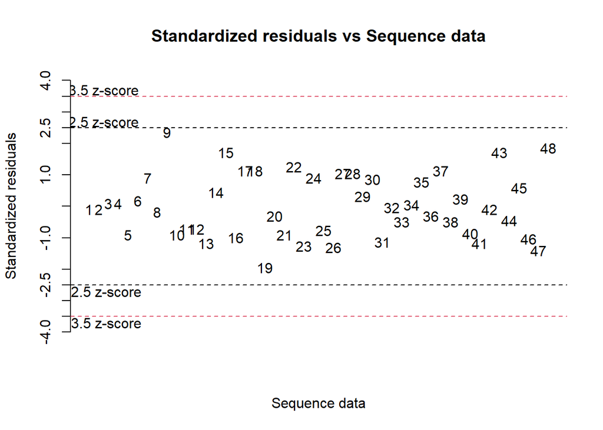

```
                                    values
p.value Shapiro-Wilk test           0.2785
p.value Bartlett test (factor_1)    0.5185
p.value Bartlett test (factor_2)    0.9064
p.value Bartlett test (treatments)  0.1708
coefficient of variation (%)       49.8800
first value most discrepant         9.0000
second value most discrepant       19.0000
third value most discrepant        48.0000
```

- Pelo teste Shapiro-Wilk, os resíduos são normalmente distribuídos (p> 0.05).
- Pelo teste de Bartlett, as variâncias dos fatores são iguais (p>0.05).

##### ANOVA

**Anova da Incidência**

**Antes da primeira aplicação (0DAA)**

| Tratamento | df | type III SS | mean square | F value | p>F |
| --- | --- | --- | --- | --- | --- |
| Adjuvante | 3 | 72.0000 | 24.0000 | 0.3091 | 0.8187 |
| Taxa | 2 | 188.6667 | 94.3333 | 1.2148 | 0.3097 |
| Blocos | 3 | 4325.3333 | 1441.7778 | 18.5661 | <0.001 |
| Ajuvante:Taxa | 6 | 174.0000 | 29.0000 | 0.3734 | 0.8906 |
| Resíduos | 33 | 2562.6667 | 77.6566 | - | - |

**valor de α = 0.05**

Pela análise de variância a 5% de significância:

- NÃO há diferença significativa entre os níveis do fator (p > 0.05);
- Há SIM diferença significativa entre blocos (p < 0.05);
- NÃO há interação entre os fatores (p > 0.05).

#### II - Com testemunha

##### Pressupostos

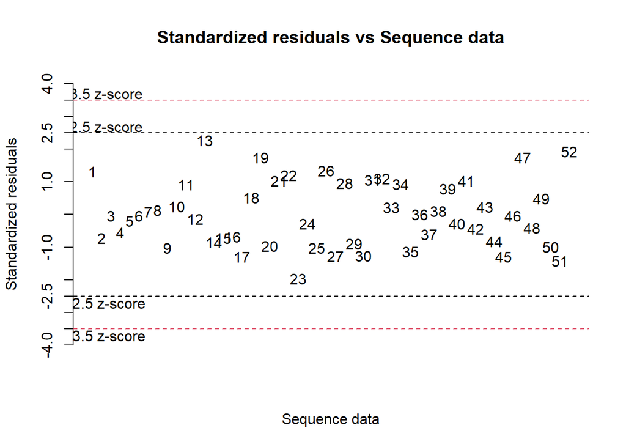

```
                              values
p.value Shapiro-Wilk test     0.2229
p.value Bartlett test         0.9784
coefficient of variation (%) 47.7800
first value most discrepant  13.0000
second value most discrepant 23.0000
third value most discrepant  52.0000
```

```
    Lilliefors (Kolmogorov-Smirnov) normality test

data:  Inc_d0A_COM_c_anova$`Residual analysis`$residuals
D = 0.090015, p-value = 0.366
```

- Pelo teste Shapiro-Wilk, os resíduos são normalmente distribuídos (p> 0.05).
- Pelo teste de Bartlett, as variâncias dos tratamentos são iguais (p>0.05).

##### ANOVA

```
           df type III SS mean square F value    p>F
treatments 12    582.7692     48.5641  0.6455 0.7893
blocks      3   4499.6923   1499.8974 19.9373 <0.001
residuals  36   2708.3077     75.2308       -      -
```

Pela análise de variância a 5% de significância:

- NÃO há diferença significativa entre os tratamentos (p > 0.05);
- Há SIM diferença significativa entre blocos (p < 0.05).

O gráfico abaixo representa visualmente a incidência em cada tratamento no dia zero (0).

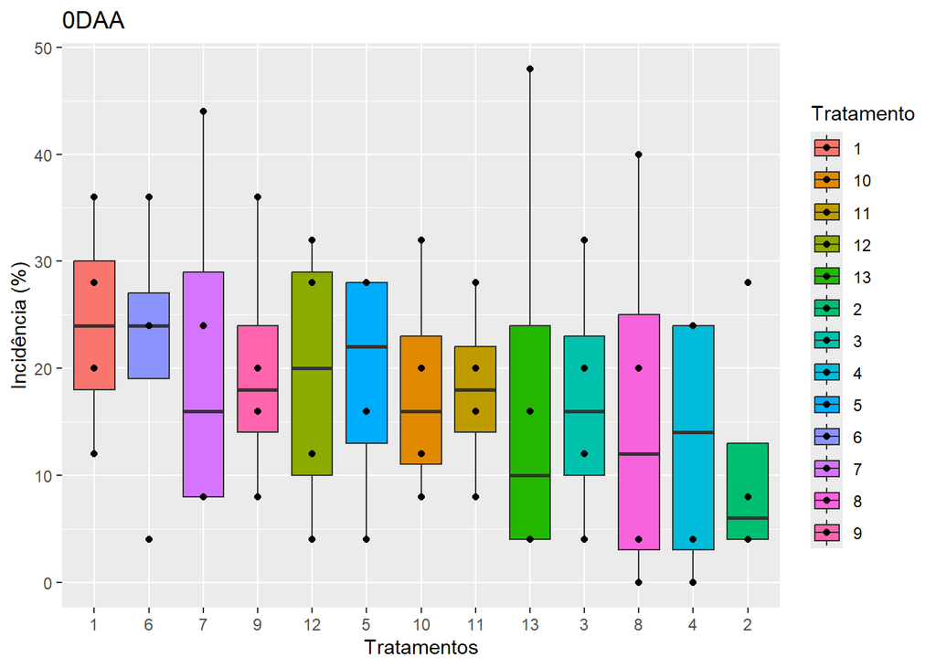

### b. D3AA

#### I - Sem testemunha

##### Pressupostos da ANOVA

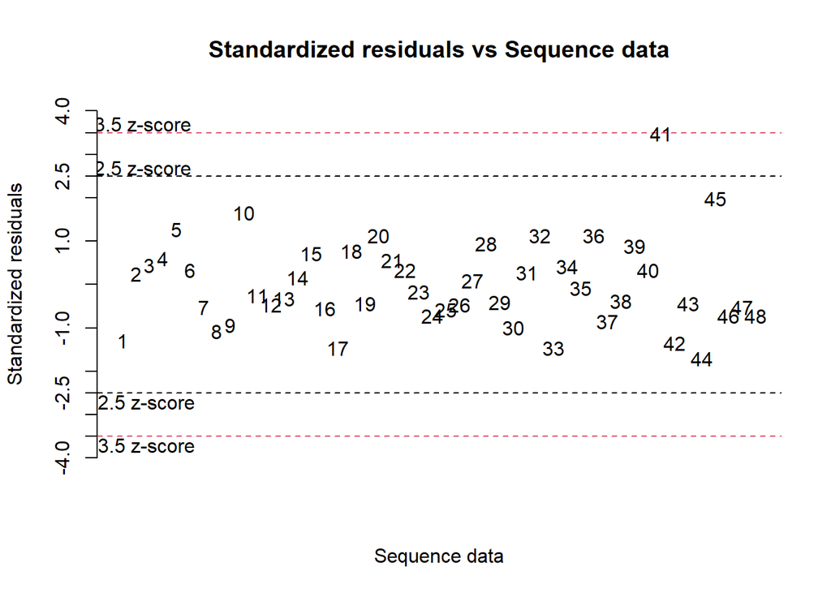

```
                                    values
p.value Shapiro-Wilk test           0.0409
p.value Bartlett test (factor_1)    0.1500
p.value Bartlett test (factor_2)    0.0561
p.value Bartlett test (treatments)  0.4530
coefficient of variation (%)       51.1800
first value most discrepant        41.0000
second value most discrepant       45.0000
third value most discrepant        44.0000
```

```
    Lilliefors (Kolmogorov-Smirnov) normality test

data:  Inc_d3A_sem_c_anova$`Residual analysis`$residuals
D = 0.10456, p-value = 0.2105
```

- Pelo teste Shapiro-Wilk, os resíduos são “quase” normalmente distribuídos (p = 0.041), mas pelo teste de Lilliefors, os resíduos são normalmente distribuídos (p> 0.05).
- Pelo teste de Bartlett, as variâncias dos fatores são iguais (p>0.05).

##### ANOVA

**Anova da Incidência**

**Três dias após a primeira aplicação (3DAA)**

| Tratamento | df | type III SS | mean square | F value | p>F |
| --- | --- | --- | --- | --- | --- |
| Adjuvante | 3 | 313.0000 | 104.3333 | 0.5708 | 0.6382 |
| Taxa | 2 | 228.6667 | 114.3333 | 0.6255 | 0.5412 |
| Blocos | 3 | 2555.6667 | 851.8889 | 4.6603 | 0.008 |
| Ajuvante:Taxa | 6 | 590.0000 | 98.3333 | 0.5379 | 0.7755 |
| Resíduos | 33 | 6032.3333 | 182.7980 | - | - |

**valor de α = 0.05**

Pela análise de variância a 5% de significância:

- NÃO há diferença significativa entre os níveis do fator (p > 0.05);
- Há SIM diferença significativa entre blocos (p < 0.05);
- NÃO há interação entre os fatores (p > 0.05).

#### II - Com testemunha

##### Pressupostos

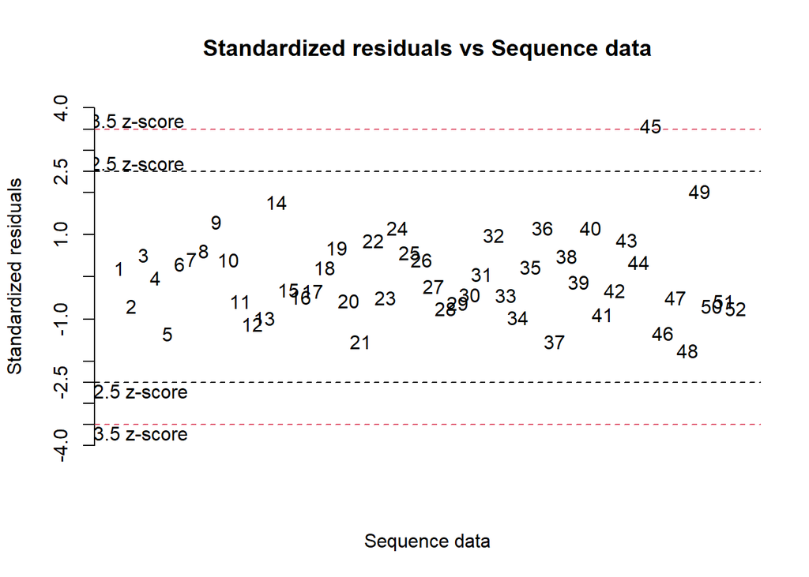

```
                              values
p.value Shapiro-Wilk test     0.0324
p.value Bartlett test         0.5469
coefficient of variation (%) 49.6200
first value most discrepant  45.0000
second value most discrepant 49.0000
third value most discrepant  14.0000
```

```
    Lilliefors (Kolmogorov-Smirnov) normality test

data:  Inc_d3A_COM_c_anova$`Residual analysis`$residuals
D = 0.10196, p-value = 0.1946
```

- Pelo teste Shapiro-Wilk, os resíduos NÃO são normalmente distribuídos (p = 0.0324), mas pelo teste de Lilliefors, os resíduos são normalmente distribuídos (p > 0.05)
- Pelo teste de Bartlett, as variâncias dos tratamentos são iguais (p>0.05).

##### ANOVA

```
           df type III SS mean square F value    p>F
treatments 12    1139.077     94.9231   0.557 0.8611
blocks      3    2881.231    960.4103  5.6359 0.0028
residuals  36    6134.769    170.4103       -      -
```

Pela análise de variância a 5% de significância:

- NÃO há diferença significativa entre os tratamentos (p > 0.05);
- Há SIM diferença significativa entre blocos (p < 0.05).

O gráfico abaixo representa visualmente a incidência em cada tratamento no dia 3DAA.

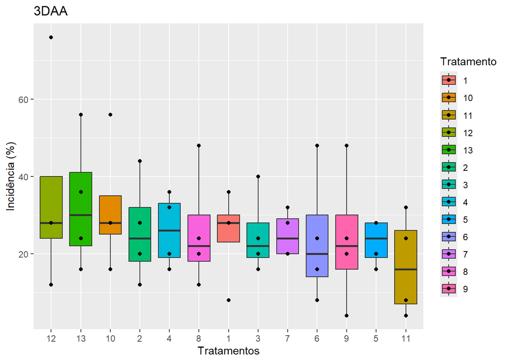

### c. D7AA

#### I - Sem testemunha

##### Pressupostos da ANOVA

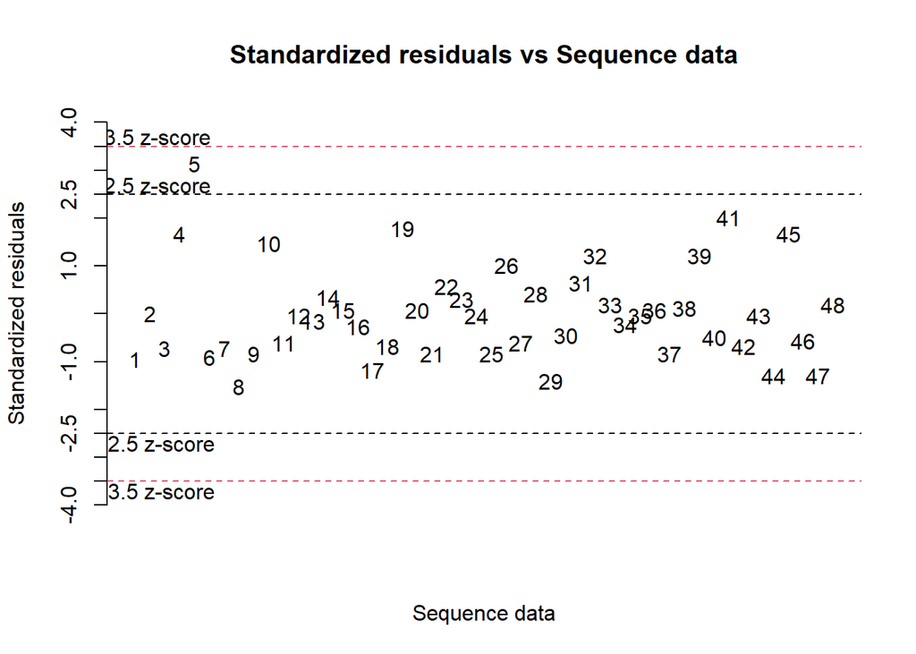

```
                                    values
p.value Shapiro-Wilk test           0.0077
p.value Bartlett test (factor_1)    0.6984
p.value Bartlett test (factor_2)    0.5364
p.value Bartlett test (treatments)  0.0724
coefficient of variation (%)       50.0700
first value most discrepant         5.0000
second value most discrepant       41.0000
third value most discrepant        19.0000
```

```
    Lilliefors (Kolmogorov-Smirnov) normality test

data:  Inc_d7A_sem_c_anova$`Residual analysis`$residuals
D = 0.13331, p-value = 0.03242
```

##### ANOVA

**Anova da Incidência**

**Sete dias após a primeira aplicação (7DAA)**

| Tratamento | df | type III SS | mean square | F value | p>F |
| --- | --- | --- | --- | --- | --- |
| Adjuvante | 3 | 74.6667 | 24.8889 | 0.2251 | 0.8782 |
| Taxa | 2 | 32.0000 | 16.0000 | 0.1447 | 0.8658 |
| Blocos | 3 | 1800.0000 | 600.0000 | 5.4276 | 0.0038 |
| Ajuvante:Taxa | 6 | 189.3333 | 31.5556 | 0.2855 | 0.9397 |
| Resíduos | 33 | 3648.0000 | 110.5455 | - | - |

**valor de α = 0.05**

Pela análise de variância a 5% de significância:

- NÃO há diferença significativa entre os níveis do fator (p > 0.05);
- Há SIM diferença significativa entre blocos (p < 0.05);
- NÃO há interação entre os fatores (p > 0.05).

#### II - Com testemunha

##### Pressupostos

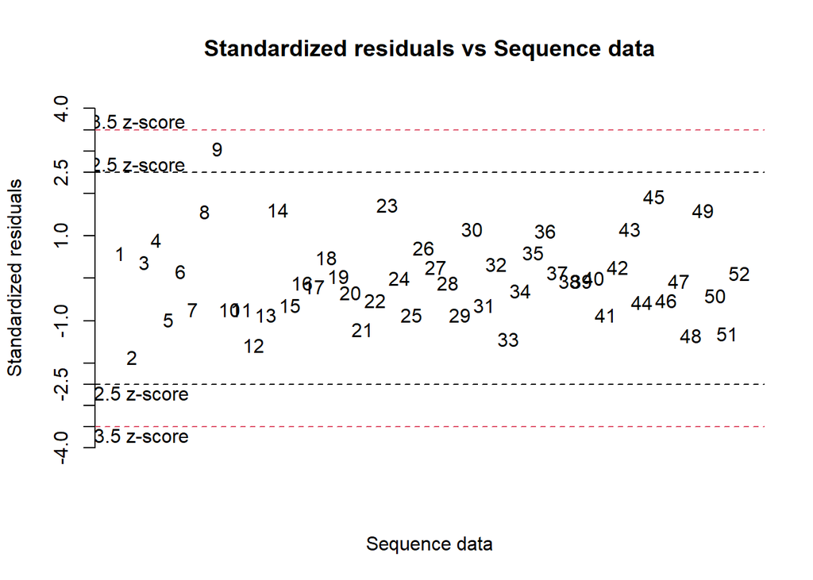

```
                              values
p.value Shapiro-Wilk test     0.1630
p.value Bartlett test         0.3817
coefficient of variation (%) 46.7900
first value most discrepant   9.0000
second value most discrepant 45.0000
third value most discrepant   2.0000
```

- Pelo teste Shapiro-Wilk, os resíduos são normalmente distribuídos (p > 0.05);
- Pelo teste de Bartlett, as variâncias dos tratamentos são iguais (p>0.05).

##### ANOVA

```
           df type III SS mean square F value    p>F
treatments 12    2083.077    173.5897  1.5398 0.1552
blocks      3    2297.539    765.8462  6.7933  0.001
residuals  36    4058.461    112.7350       -      -
```

Pela análise de variância a 5% de significância:

- NÃO há diferença significativa entre os tratamentos (p > 0.05);
- Há SIM diferença significativa entre blocos (p < 0.05).

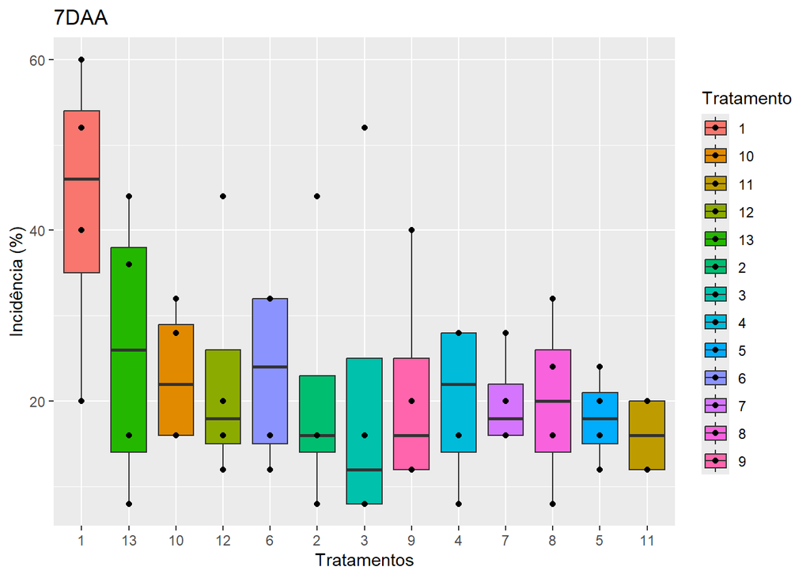

### d. D3AB

#### I - Sem testemunha

##### Pressupostos da ANOVA

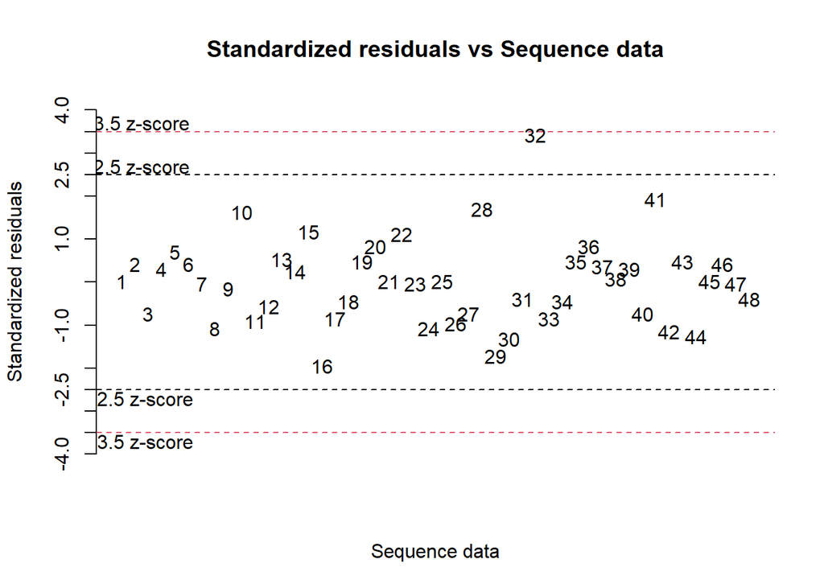

```
                                    values
p.value Shapiro-Wilk test           0.0814
p.value Bartlett test (factor_1)    0.0213
p.value Bartlett test (factor_2)    0.1491
p.value Bartlett test (treatments)  0.1404
coefficient of variation (%)       31.1400
first value most discrepant        32.0000
second value most discrepant       16.0000
third value most discrepant        41.0000
```

```
    Lilliefors (Kolmogorov-Smirnov) normality test

data:  Inc_d3B_sem_c_anova$`Residual analysis`$residuals
D = 0.10878, p-value = 0.1663
```

- Pelo teste Shapiro-Wilk, os resíduos são normalmente distribuídos (p> 0.05).
- Pelo teste de Bartlett, as variâncias do fator 2 (Taxa) e dos tratamentos são iguais (p>0.05), enquanto que no fator 1 (Adjuvante), não (p = 0.0213).

##### ANOVA

**Anova da Incidência**

**Três dias após a segunda aplicação (3DAB)**

| Tratamento | df | type III SS | mean square | F value | p>F |
| --- | --- | --- | --- | --- | --- |
| Adjuvante | 3 | 97.0000 | 32.3333 | 0.6838 | 0.5683 |
| Taxa | 2 | 60.6667 | 30.3333 | 0.6415 | 0.5329 |
| Blocos | 3 | 707.6667 | 235.8889 | 4.9889 | 0.0058 |
| Ajuvante:Taxa | 6 | 38.0000 | 6.3333 | 0.1339 | 0.9909 |
| Resíduos | 33 | 1560.3333 | 47.2828 | - | - |

**valor de α = 0.05**

Pela análise de variância a 5% de significância:

- NÃO há diferença significativa entre os níveis do fator (p > 0.05);
- Há SIM diferença significativa entre blocos (p < 0.05);
- NÃO há interação entre os fatores (p > 0.05).

#### II - Com testemunha

##### Pressupostos

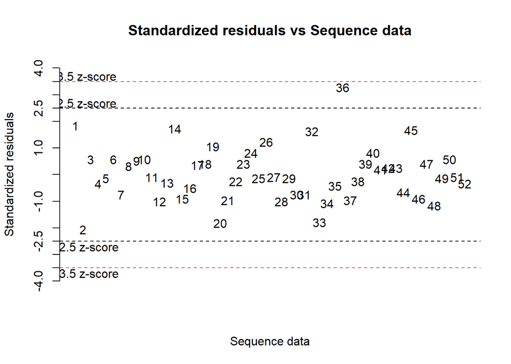

```
                              values
p.value Shapiro-Wilk test     0.1435
p.value Bartlett test         0.0399
coefficient of variation (%) 30.0400
first value most discrepant  36.0000
second value most discrepant  2.0000
third value most discrepant   1.0000
```

```
    Lilliefors (Kolmogorov-Smirnov) normality test

data:  Inc_d3B_COM_c_anova$`Residual analysis`$residuals
D = 0.11138, p-value = 0.1106
```

- Pelo teste Shapiro-Wilk, os resíduos são normalmente distribuídos (p > 0.05);
- Pelo teste de Bartlett, as variâncias dos tratamentos são “quase” iguais (p = 0.040).

##### ANOVA

```
           df type III SS mean square F value    p>F
treatments 12   2675.6923    222.9744  4.2627 <0.001
blocks      3    800.9231    266.9744  5.1039 0.0048
residuals  36   1883.0769     52.3077       -      -
```

Pela análise de variância a 5% de significância:

- Há SIM diferença significativa entre os tratamentos (p < 0.05);
- Há SIM diferença significativa entre blocos (p < 0.05).

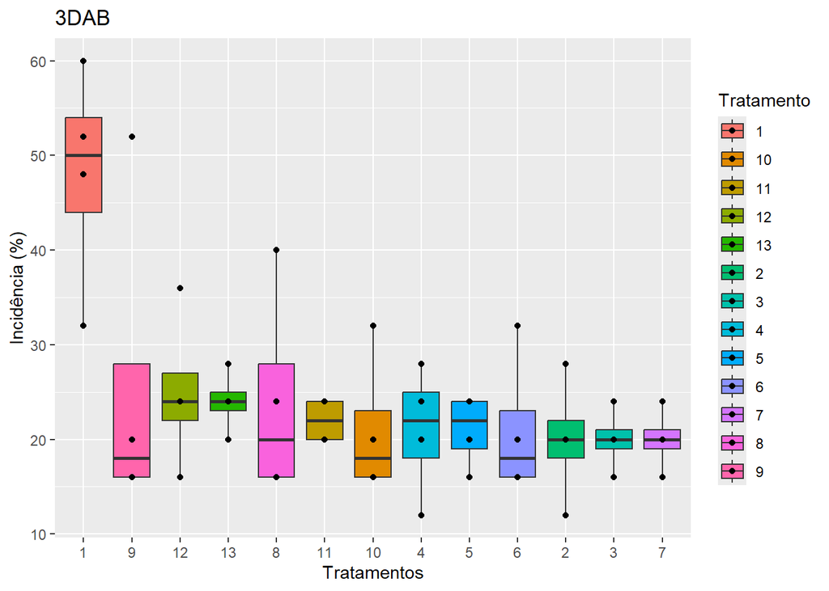

### e. D7AB

#### I - Sem testemunha

##### Pressupostos da ANOVA

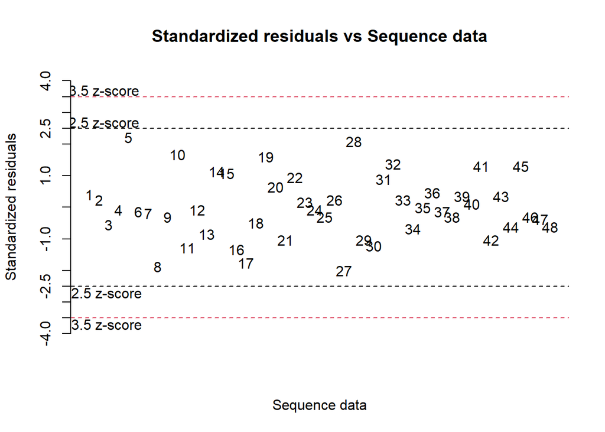

```
                                    values
p.value Shapiro-Wilk test           0.7213
p.value Bartlett test (factor_1)    0.6646
p.value Bartlett test (factor_2)    0.0691
p.value Bartlett test (treatments)  0.2453
coefficient of variation (%)       50.0000
first value most discrepant         5.0000
second value most discrepant       28.0000
third value most discrepant        27.0000
```

```
    Lilliefors (Kolmogorov-Smirnov) normality test

data:  Inc_d7B_sem_c_anova$`Residual analysis`$residuals
D = 0.077587, p-value = 0.6663
```

- Pelo teste Shapiro-Wilk, os resíduos são normalmente distribuídos (p> 0.05).
- Pelo teste de Bartlett, as variâncias dos fatores e dos tratamentos são iguais (p>0.05).

##### ANOVA

**Anova da Incidência**

**Sete dias após a segunda aplicação (7DAB)**

| Tratamento | df | type III SS | mean square | F value | p>F |
| --- | --- | --- | --- | --- | --- |
| Adjuvante | 3 | 57.0000 | 19.0000 | 0.4329 | 0.7308 |
| Taxa | 2 | 114.0000 | 57.0000 | 1.2987 | 0.2865 |
| Blocos | 3 | 467.6667 | 155.8889 | 3.5519 | 0.0248 |
| Ajuvante:Taxa | 6 | 190.0000 | 31.6667 | 0.7215 | 0.6352 |
| Resíduos | 33 | 1448.3333 | 43.8889 | - | - |

**valor de α = 0.05**

Pela análise de variância a 5% de significância:

- NÃO há diferença significativa entre os níveis do fator (p > 0.05);
- Há SIM diferença significativa entre blocos (p < 0.05);
- NÃO há interação entre os fatores (p > 0.05).

#### II - Com testemunha

##### Pressupostos

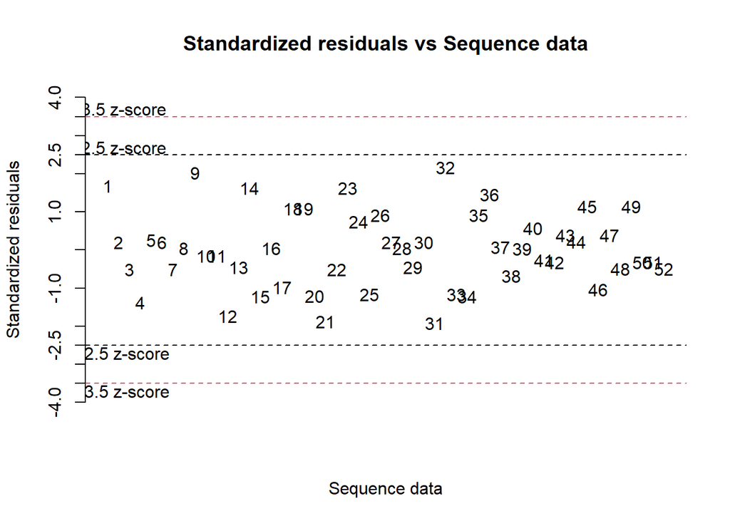

```
                              values
p.value Shapiro-Wilk test     0.4548
p.value Bartlett test         0.5471
coefficient of variation (%) 51.6200
first value most discrepant  32.0000
second value most discrepant  9.0000
third value most discrepant  31.0000
```

```
    Lilliefors (Kolmogorov-Smirnov) normality test

data:  Inc_d7B_COM_c_anova$`Residual analysis`$residuals
D = 0.09003, p-value = 0.3658
```

- Pelo teste Shapiro-Wilk, os resíduos são normalmente distribuídos (p > 0.05);
- Pelo teste de Bartlett, as variâncias dos tratamentos iguais (p > 0.05)).

##### ANOVA

```
           df type III SS mean square F value    p>F
treatments 12    400.0000     33.3333  0.7403 0.7037
blocks      3    567.0769    189.0256  4.1982  0.012
residuals  36   1620.9231     45.0256       -      -
```

Pela análise de variância a 5% de significância:

- NÃO há diferença significativa entre os tratamentos (p > 0.05);
- Há SIM diferença significativa entre blocos (p < 0.05).

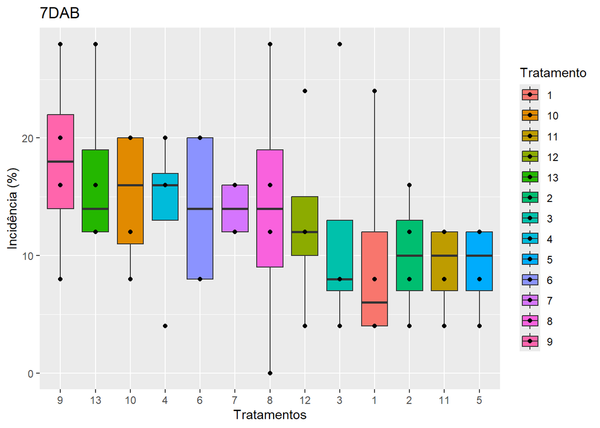

# 2. Severidade (Escala Davis)

Para avaliar a Severidade, medida segundo os parâmetros da Escala Davis, consideramos as médias dos valores aferidos nas 25 plantas dentro de cada Bloco.

Dessa forma, obtivemos quatro valores de severidade por tratamento.

## 2.1. Visualização dos Dados

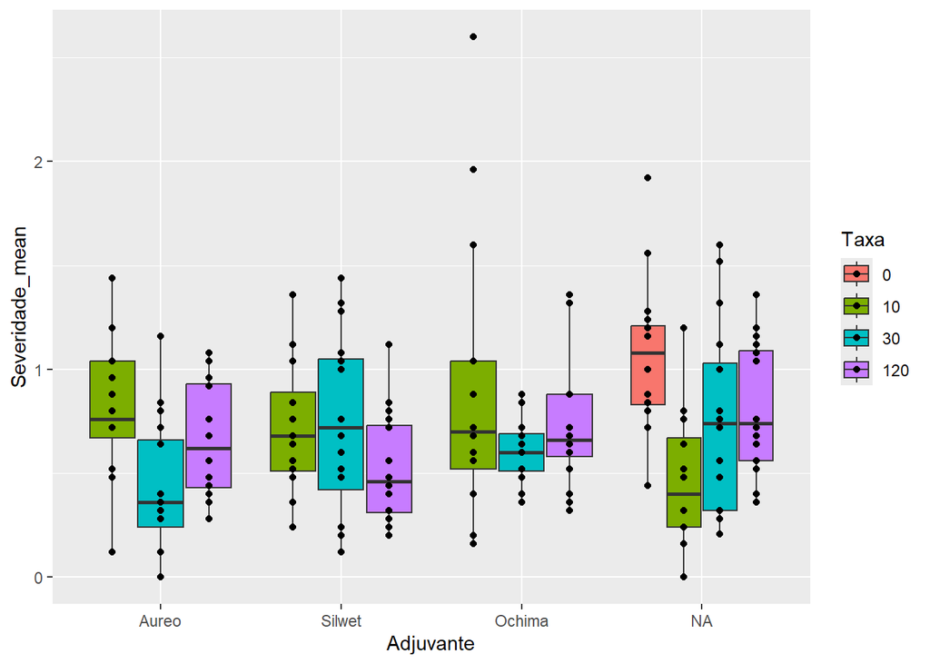

Na figura abaixo está representada o efeito das taxas de aplicação e adjuvantes sobre a severidade ao longo do tempo.

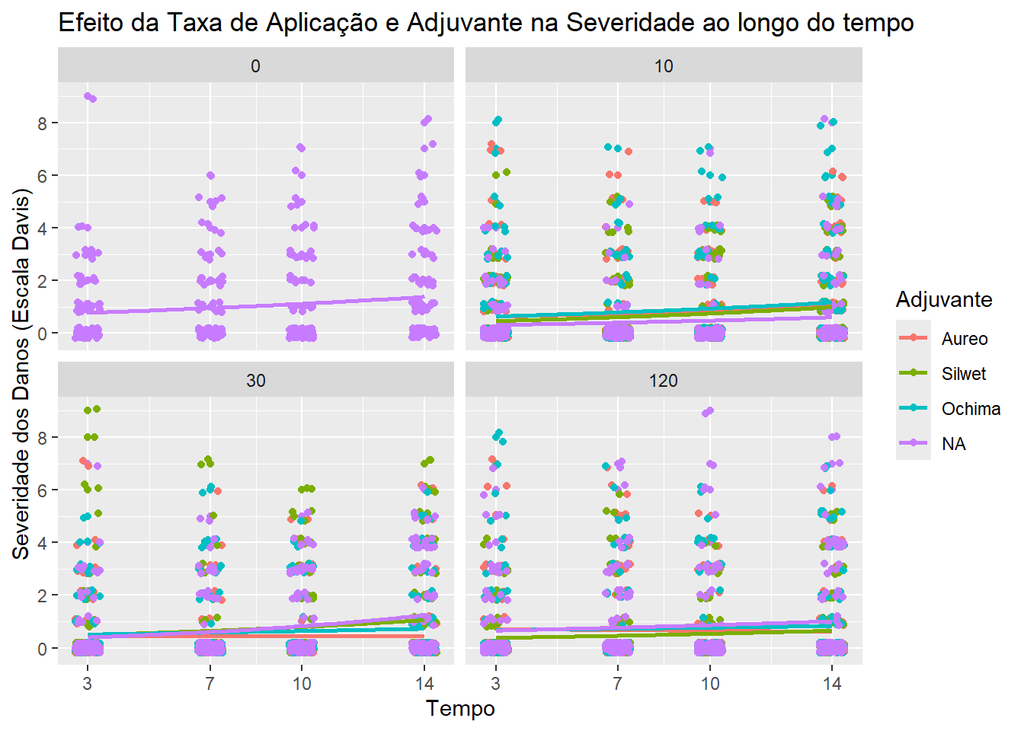

## 2.2. Análise Descritiva

**Produtividade**

| **Tratamento** | **Adjuvante** | **Taxa** | Dias | **Média** | **Desvio** |
| --- | --- | --- | --- | --- | --- |
| 1 | NA | NA | 0DAA | 24 | 10.33 |
| 2 | Aureo | 10 | 0DAA | 11 | 11.49 |
| 3 | Silwet | 10 | 0DAA | 17 | 11.94 |
| 4 | Ochima | 10 | 0DAA | 13 | 12.81 |
| 5 | NA | 10 | 0DAA | 19 | 11.49 |
| 6 | Aureo | 30 | 0DAA | 22 | 13.27 |
| 7 | Silwet | 30 | 0DAA | 21 | 17.09 |
| 8 | Ochima | 30 | 0DAA | 16 | 18.18 |
| 9 | NA | 30 | 0DAA | 20 | 11.78 |
| 10 | Aureo | 120 | 0DAA | 18 | 10.58 |
| 11 | Silwet | 120 | 0DAA | 18 | 8.33 |
| 12 | Ochima | 120 | 0DAA | 19 | 13.22 |
| 13 | NA | 120 | 0DAA | 18 | 20.78 |
| 1 | NA | NA | 3DAA | 25 | 11.94 |
| 2 | Aureo | 10 | 3DAA | 26 | 13.66 |
| 3 | Silwet | 10 | 3DAA | 25 | 10.52 |
| 4 | Ochima | 10 | 3DAA | 26 | 9.52 |
| 5 | NA | 10 | 3DAA | 23 | 6.00 |
| 6 | Aureo | 30 | 3DAA | 24 | 17.28 |
| 7 | Silwet | 30 | 3DAA | 25 | 6.00 |
| 8 | Ochima | 30 | 3DAA | 26 | 15.49 |
| 9 | NA | 30 | 3DAA | 24 | 18.18 |
| 10 | Aureo | 120 | 3DAA | 32 | 16.97 |
| 11 | Silwet | 120 | 3DAA | 17 | 13.22 |
| 12 | Ochima | 120 | 3DAA | 36 | 27.71 |
| 13 | NA | 120 | 3DAA | 33 | 17.40 |
| 1 | NA | NA | 7DAA | 43 | 17.40 |
| 2 | Aureo | 10 | 7DAA | 21 | 15.79 |
| 3 | Silwet | 10 | 7DAA | 21 | 21.01 |
| 4 | Ochima | 10 | 7DAA | 20 | 9.80 |
| 5 | NA | 10 | 7DAA | 18 | 5.16 |
| 6 | Aureo | 30 | 7DAA | 23 | 10.52 |
| 7 | Silwet | 30 | 7DAA | 20 | 5.66 |
| 8 | Ochima | 30 | 7DAA | 20 | 10.33 |
| 9 | NA | 30 | 7DAA | 21 | 13.22 |
| 10 | Aureo | 120 | 7DAA | 23 | 8.25 |
| 11 | Silwet | 120 | 7DAA | 16 | 4.62 |
| 12 | Ochima | 120 | 7DAA | 23 | 14.38 |
| 13 | NA | 120 | 7DAA | 26 | 16.81 |
| 1 | NA | NA | 3DAB | 48 | 11.78 |
| 2 | Aureo | 10 | 3DAB | 20 | 6.53 |
| 3 | Silwet | 10 | 3DAB | 20 | 3.27 |
| 4 | Ochima | 10 | 3DAB | 21 | 6.83 |
| 5 | NA | 10 | 3DAB | 21 | 3.83 |
| 6 | Aureo | 30 | 3DAB | 21 | 7.57 |
| 7 | Silwet | 30 | 3DAB | 20 | 3.27 |
| 8 | Ochima | 30 | 3DAB | 24 | 11.31 |
| 9 | NA | 30 | 3DAB | 26 | 17.44 |
| 10 | Aureo | 120 | 3DAB | 21 | 7.57 |
| 11 | Silwet | 120 | 3DAB | 22 | 2.31 |
| 12 | Ochima | 120 | 3DAB | 25 | 8.25 |
| 13 | NA | 120 | 3DAB | 24 | 3.27 |
| 1 | NA | NA | 7DAB | 10 | 9.52 |
| 2 | Aureo | 10 | 7DAB | 10 | 5.16 |
| 3 | Silwet | 10 | 7DAB | 12 | 10.83 |
| 4 | Ochima | 10 | 7DAB | 14 | 6.93 |
| 5 | NA | 10 | 7DAB | 9 | 3.83 |
| 6 | Aureo | 30 | 7DAB | 14 | 6.93 |
| 7 | Silwet | 30 | 7DAB | 14 | 2.31 |
| 8 | Ochima | 30 | 7DAB | 14 | 11.55 |
| 9 | NA | 30 | 7DAB | 18 | 8.33 |
| 10 | Aureo | 120 | 7DAB | 15 | 6.00 |
| 11 | Silwet | 120 | 7DAB | 9 | 3.83 |
| 12 | Ochima | 120 | 7DAB | 13 | 8.25 |
| 13 | NA | 120 | 7DAB | 17 | 7.57 |

## 2.3. Análise Inferencial

### a. 3DAA

#### I - Sem testemunha

##### Pressupostos da ANOVA

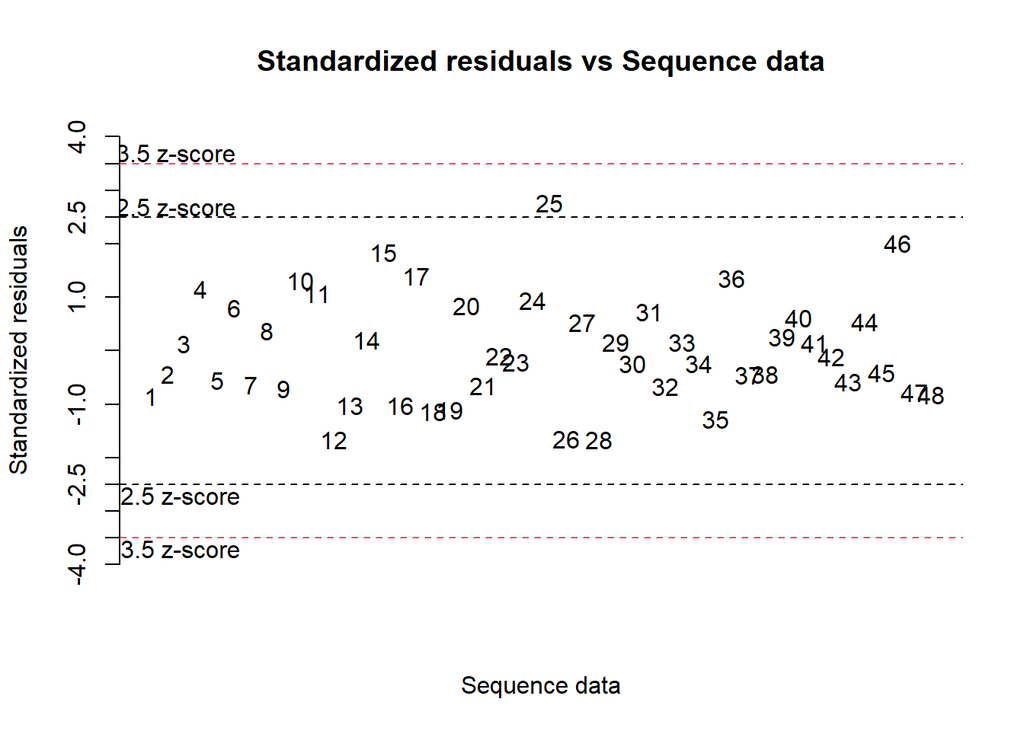

```
                                    values
p.value Shapiro-Wilk test           0.3157
p.value Bartlett test (factor_1)    0.4789
p.value Bartlett test (factor_2)    0.1937
p.value Bartlett test (treatments)  0.3323
coefficient of variation (%)       58.0400
first value most discrepant        25.0000
second value most discrepant       46.0000
third value most discrepant        15.0000
```

- Pelo teste Shapiro-Wilk, os resíduos são normalmente distribuídos (p> 0.05).
- Pelo teste de Bartlett, as variâncias dos fatores são iguais (p>0.05).

##### ANOVA

**Anova da Escala Davis**

**Três dias após primeira aplicação (3DAA)**

| Tratamento | df | type III SS | mean square | F value | p>F |
| --- | --- | --- | --- | --- | --- |
| Adjuvante | 3 | 0.3790 | 0.1263 | 0.9964 | 0.4067 |
| Taxa | 2 | 0.1520 | 0.0760 | 0.5996 | 0.5549 |
| Blocos | 3 | 0.2986 | 0.0995 | 0.7851 | 0.5108 |
| Ajuvante:Taxa | 6 | 0.3470 | 0.0578 | 0.4561 | 0.8354 |
| Resíduos | 33 | 4.1840 | 0.1268 | - | - |

**valor de α = 0.05**

Pela análise de variância a 5% de significância:

- NÃO há diferença significativa entre os níveis do fator (p > 0.05);
- NÃO há diferença significativa entre blocos (p > 0.05);
- NÃO há interação entre os fatores (p > 0.05).

#### II - Com testemunha

##### Pressupostos

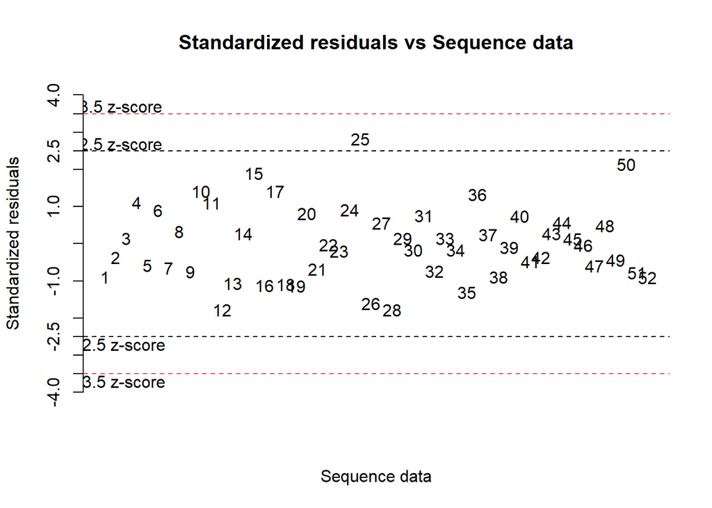

```
                              values
p.value Shapiro-Wilk test     0.4330
p.value Bartlett test         0.7349
coefficient of variation (%) 55.1300
first value most discrepant  25.0000
second value most discrepant 50.0000
third value most discrepant  15.0000
```

- Pelo teste Shapiro-Wilk, os resíduos são normalmente distribuídos (p> 0.05).
- Pelo teste de Bartlett, as variâncias dos tratamentos são iguais (p>0.05).

##### ANOVA

```
           df type III SS mean square F value    p>F
treatments 12      1.0064      0.0839  0.7001 0.7407
blocks      3      0.4417      0.1472   1.229 0.3133
residuals  36      4.3129      0.1198       -      -
```

Pela análise de variância a 5% de significância:

- NÃO há diferença significativa entre os tratamentos (p > 0.05);
- NÃO há diferença significativa entre blocos (p > 0.05).

O gráfico abaixo representa visualmente a severidade em cada tratamento no dia 3DAA.

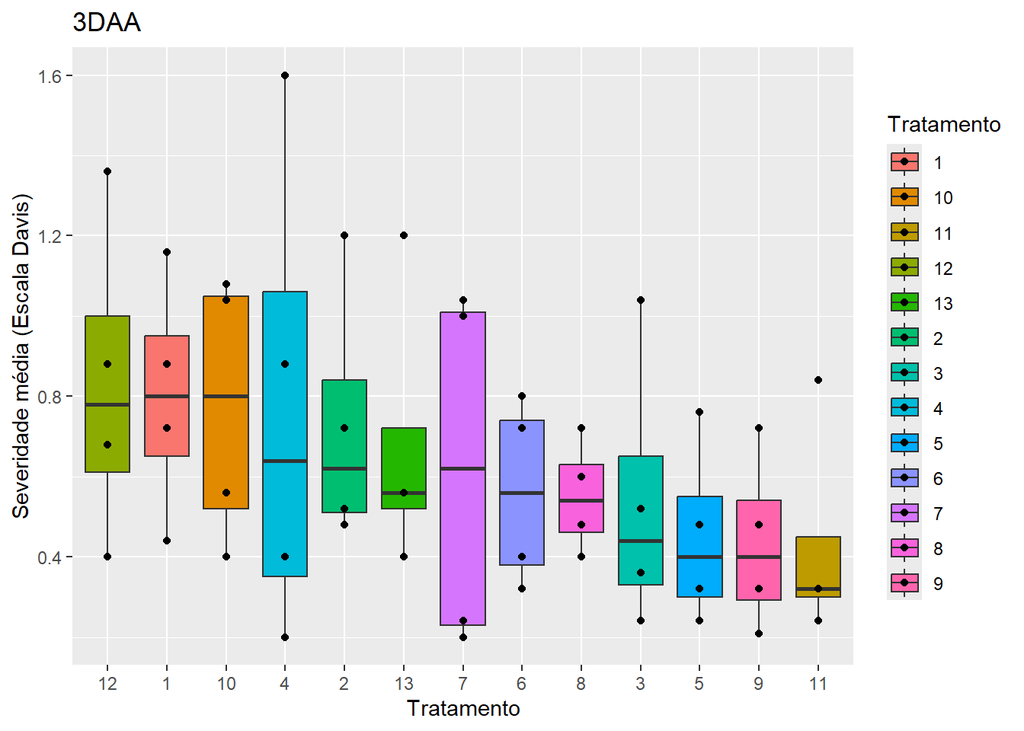

### b. 7DAA

#### I - Sem testemunha

##### Pressupostos da ANOVA

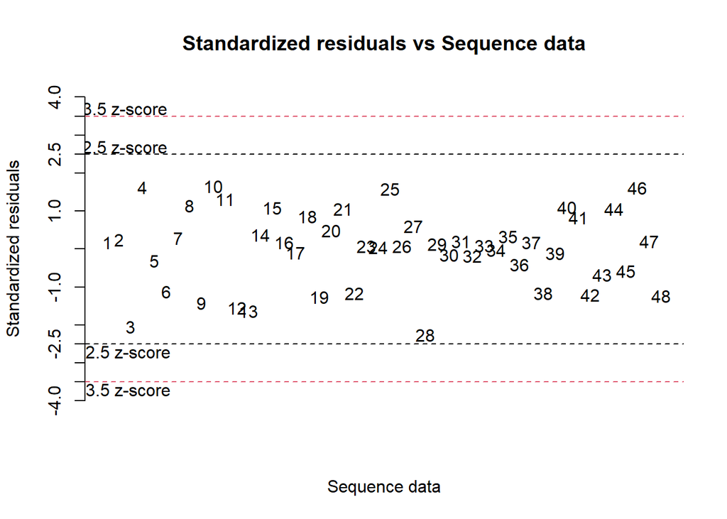

```
                                    values
p.value Shapiro-Wilk test           0.1168
p.value Bartlett test (factor_1)    0.5311
p.value Bartlett test (factor_2)    0.2728
p.value Bartlett test (treatments)  0.1872
coefficient of variation (%)       48.8600
first value most discrepant        28.0000
second value most discrepant        3.0000
third value most discrepant        10.0000
```

- Pelo teste Shapiro-Wilk, os resíduos são normalmente distribuídos (p>0.05).
- Pelo teste de Bartlett, as variâncias dos fatores são iguais (p>0.05).

##### ANOVA

**Anova da Escala Davies**

**Sete dias após primeira aplicação (7DAA)**

| df | type III SS | mean square | F value | p>F |
| --- | --- | --- | --- | --- |
| 3 | 0.1004 | 0.0335 | 0.4591 | 0.7127 |
| 2 | 0.1448 | 0.0724 | 0.9936 | 0.381 |
| 3 | 0.0710 | 0.0237 | 0.325 | 0.8073 |
| 6 | 0.7245 | 0.1208 | 1.6572 | 0.1628 |
| 33 | 2.4046 | 0.0729 | - | - |

**valor de α = 0.05**

Pela análise de variância a 5% de significância:

- NÃO há diferença significativa entre os níveis do fator (p > 0.05);
- NÃO há diferença significativa entre blocos (p > 0.05);
- NÃO há interação entre os fatores (p > 0.05).

#### II - Com testemunha

##### Pressupostos

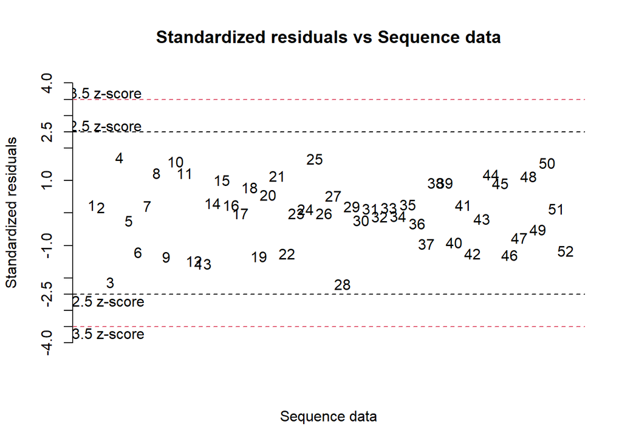

```
                              values
p.value Shapiro-Wilk test     0.1113
p.value Bartlett test         0.1535
coefficient of variation (%) 45.4900
first value most discrepant  28.0000
second value most discrepant  3.0000
third value most discrepant   4.0000
```

- Pelo teste Shapiro-Wilk, os resíduos são normalmente distribuídos (p> 0.05).
- Pelo teste de Bartlett, as variâncias dos tratamentos são iguais (p>0.05).

##### ANOVA

```
           df type III SS mean square F value    p>F
treatments 12      1.8472      0.1539  2.1372 0.0392
blocks      3      0.0459      0.0153  0.2123 0.8872
residuals  36      2.5929      0.0720       -      -
```

```
   treatment adjusted.mean     sd    sem tukey snk duncan   t scott_knott
1          1          1.04 0.2332 0.1342     a   a      a   a           a
2         13          0.78 0.2723 0.1342    ab  ab     ab  ab           a
3         10          0.69 0.3642 0.1342    ab  ab     ac  ac           a
4          2          0.65 0.3842 0.1342    ab  ab     ac  bc           a
5          4          0.65 0.3642 0.1342    ab  ab     ac  bc           a
6          8          0.62 0.0400 0.1342    ab  ab     ac bcd           a
7         12          0.59 0.0503 0.1342    ab  ab     bc bcd           a
8          3          0.58 0.2321 0.1342    ab  ab     bc bcd           a
9          9          0.54 0.2781 0.1342    ab  ab     bc bcd           a
10         7          0.47 0.2474 0.1342    ab  ab     bc bcd           a
11        11          0.45 0.2151 0.1342    ab  ab     bc bcd           a
12         6          0.36 0.2142 0.1342     b   b     bc  cd           a
13         5          0.25 0.2224 0.1342     b   b      c   d           a
```

Pela análise de variância a 5% de significância:

- Há SIM diferença significativa entre os tratamentos (p<0.05);
- NÃO há diferença significativa entre blocos (p>0.05).

O gráfico abaixo representa visualmente a severidade em cada tratamento no dia 7DAA.

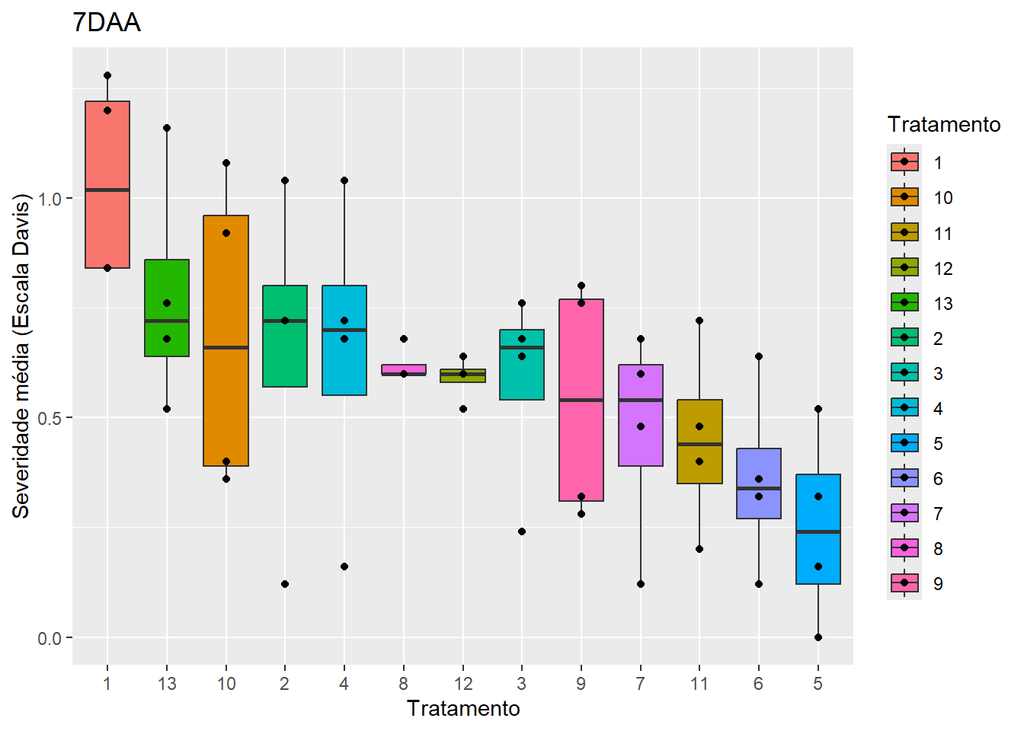

### c. 3DAB

#### I - Sem testemunha

##### Pressupostos da ANOVA

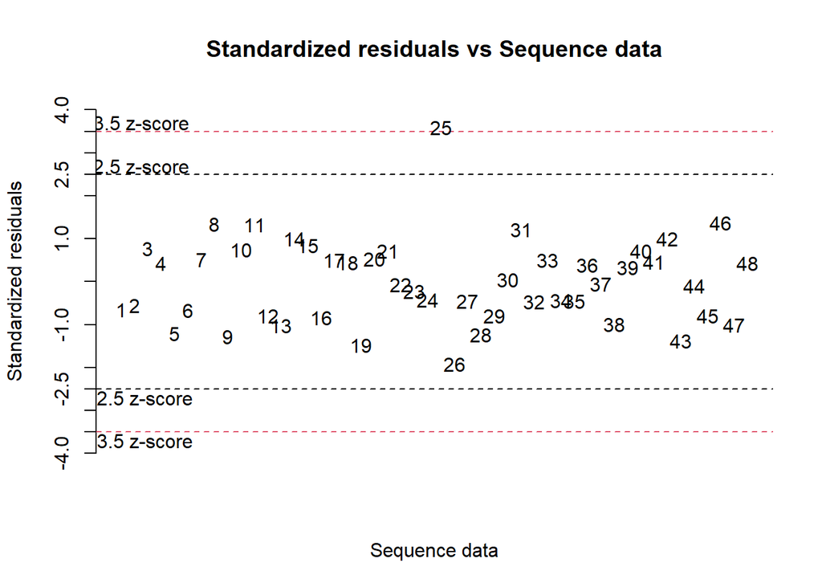

```
                                    values
p.value Shapiro-Wilk test           0.0244
p.value Bartlett test (factor_1)    0.2446
p.value Bartlett test (factor_2)    0.1652
p.value Bartlett test (treatments)  0.3345
coefficient of variation (%)       52.5600
first value most discrepant        25.0000
second value most discrepant       26.0000
third value most discrepant        19.0000
```

```
    Lilliefors (Kolmogorov-Smirnov) normality test

data:  anova_sc_3DAB$`Residual analysis`$residuals
D = 0.10193, p-value = 0.2425
```

- Pelo teste Shapiro-Wilk, os resíduos NÃO são normalmente distribuídos (p < 0.05).
- Pelo teste de Lilliefors, os resíduos são SIM normalmente distribuídos (p > 0.05).
- Pelo teste de Bartlett, as variâncias dos fatores são iguais (p>0.05).

##### ANOVA

**Anova da Escala Davis**

**Três dias após segunda aplicação (3DAB)**

| Tratamento | df | type III SS | mean square | F value | p>F |
| --- | --- | --- | --- | --- | --- |
| Adjuvante | 3 | 0.1828 | 0.0609 | 0.5832 | 0.6303 |
| Taxa | 2 | 0.0474 | 0.0237 | 0.2268 | 0.7983 |
| Blocos | 3 | 1.0935 | 0.3645 | 3.4883 | 0.0265 |
| Ajuvante:Taxa | 6 | 1.3774 | 0.2296 | 2.197 | 0.0682 |
| Resíduos | 33 | 3.4481 | 0.1045 | - | - |

**valor de α = 0.05**

Pela análise de variância a 5% de significância:

- NÃO há diferença significativa entre os níveis do fator (p > 0.05);
- Há SIM diferença significativa entre blocos (p < 0.05);
- NÃO há interação entre os fatores (p > 0.05).

#### II - Com testemunha

##### Pressupostos

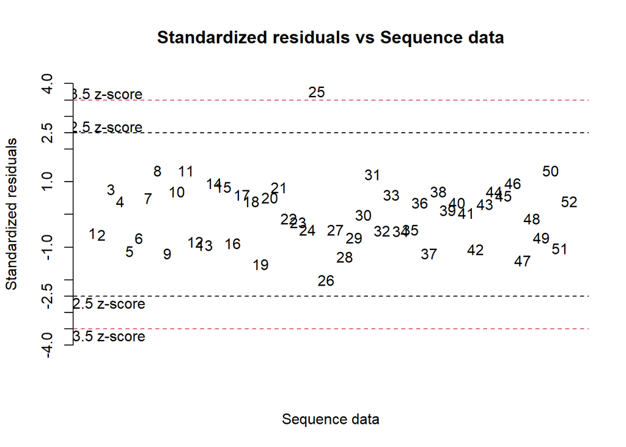

```
                              values
p.value Shapiro-Wilk test     0.0114
p.value Bartlett test         0.1676
coefficient of variation (%) 49.5200
first value most discrepant  25.0000
second value most discrepant 26.0000
third value most discrepant  19.0000
```

```
    Lilliefors (Kolmogorov-Smirnov) normality test

data:  anova_Cc_3DAB$`Residual analysis`$residuals
D = 0.10132, p-value = 0.2019
```

- Pelo teste Shapiro-Wilk, os resíduos NÃO são normalmente distribuídos (p < 0.05).
- Pelo teste de Lilliefors, os resíduos são SIM normalmente distribuídos (p > 0.05).
- Pelo teste de Bartlett, as variâncias dos tratamentos são iguais (p>0.05).

##### ANOVA

```
           df type III SS mean square F value    p>F
treatments 12      1.9740      0.1645  1.6417 0.1234
blocks      3      1.0733      0.3578  3.5707 0.0233
residuals  36      3.6071      0.1002       -      -
```

Pela análise de variância a 5% de significância:

- NÃO há diferença significativa entre os tratamentos (p > 0.05);
- Há SIM diferença significativa entre blocos (p < 0.05).

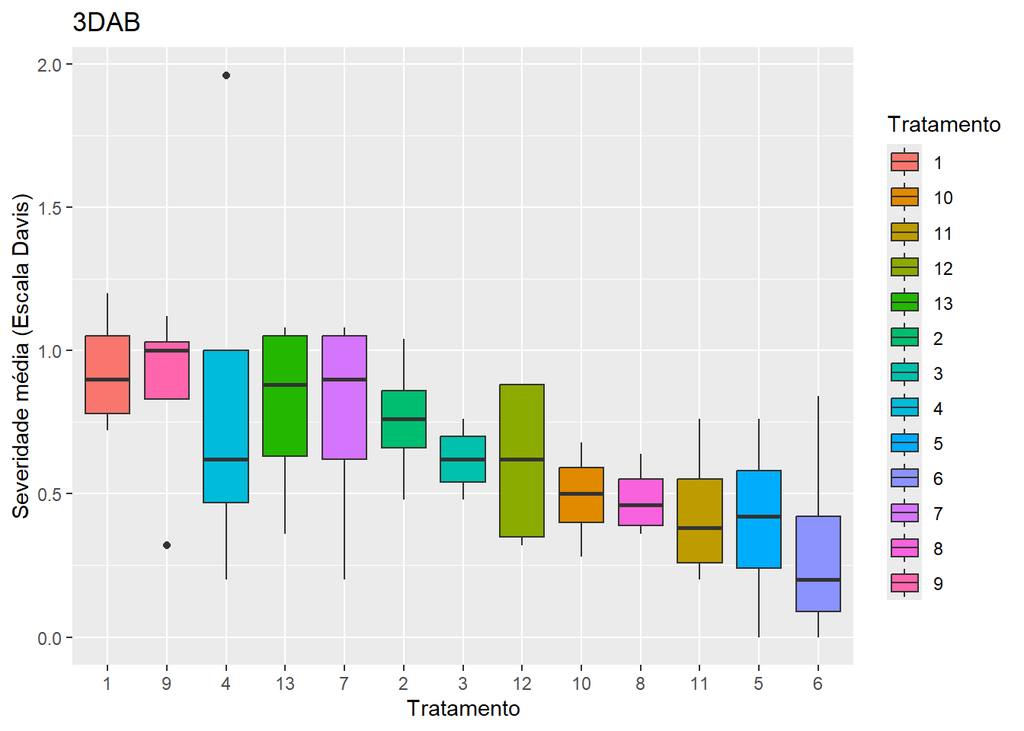

### d. 7DAB

#### I - Sem testemunha

##### Pressupostos da ANOVA

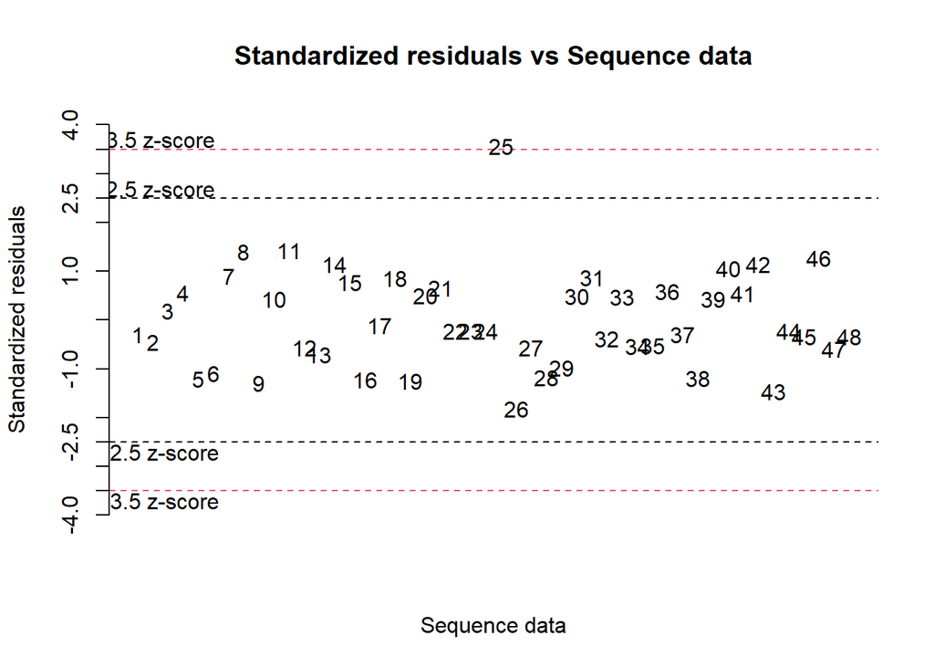

```
                                    values
p.value Shapiro-Wilk test           0.0205
p.value Bartlett test (factor_1)    0.2781
p.value Bartlett test (factor_2)    0.1045
p.value Bartlett test (treatments)  0.2620
coefficient of variation (%)       40.0900
first value most discrepant        25.0000
second value most discrepant       26.0000
third value most discrepant        43.0000
```

```
    Lilliefors (Kolmogorov-Smirnov) normality test

data:  anova_sc_7DAB$`Residual analysis`$residuals
D = 0.12787, p-value = 0.04787
```

- Pelo teste Shapiro-Wilk, os resíduos NÃO são normalmente distribuídos (p<0.05).
- Pelo teste de Lilliefors, os resíduos são “QUASE” normalmente distribuídos (p = 0.048).
- Pelo teste de Bartlett, as variâncias dos fatores são iguais (p>0.05).

##### ANOVA

**Anova da Escala Davies**

**Sete dias após segunda aplicação (7DAB)**

[output not shown]

**valor de α = 0.05**

Pela análise de variância a 5% de significância:

- NÃO há diferença significativa entre os níveis do fator (p > 0.05);
- Há SIM diferença significativa entre blocos (p < 0.05);
- NÃO há interação entre os fatores (p > 0.05).

#### II - Com testemunha

##### Pressupostos

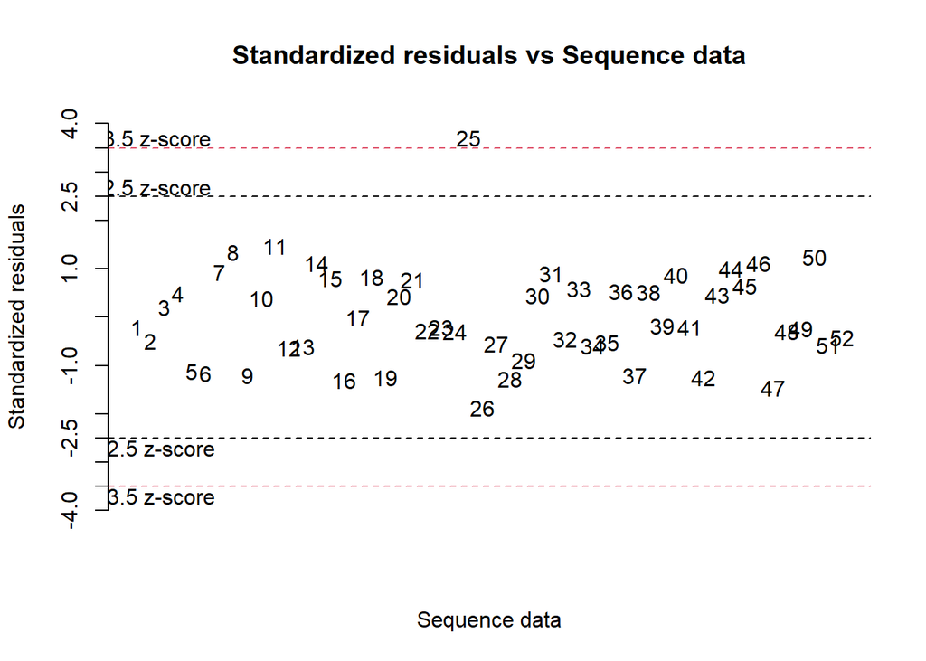

```
                              values
p.value Shapiro-Wilk test     0.0112
p.value Bartlett test         0.1573
coefficient of variation (%) 37.8700
first value most discrepant  25.0000
second value most discrepant 26.0000
third value most discrepant  47.0000
```

```
    Lilliefors (Kolmogorov-Smirnov) normality test

data:  anova_Cc_7DAB$`Residual analysis`$residuals
D = 0.10777, p-value = 0.1379
```

- Pelo teste Shapiro-Wilk, os resíduos NÃO são normalmente distribuídos (p<0.05).
- Pelo teste de Lilliefors, os resíduos são SIM normalmente distribuídos (p>0.05).
- Pelo teste de Bartlett, as variâncias dos tratamentos são iguais (p>0.05).

##### ANOVA

```
           df type III SS mean square F value    p>F
treatments 12      3.4515      0.2876  2.0183 0.0517
blocks      3      1.3632      0.4544  3.1885 0.0352
residuals  36      5.1304      0.1425       -      -
```

Pela análise de variância a 5% de significância:

- NÃO há diferença significativa entre os tratamentos (p > 0.05);
- Há SIM diferença significativa entre blocos (p < 0.05).

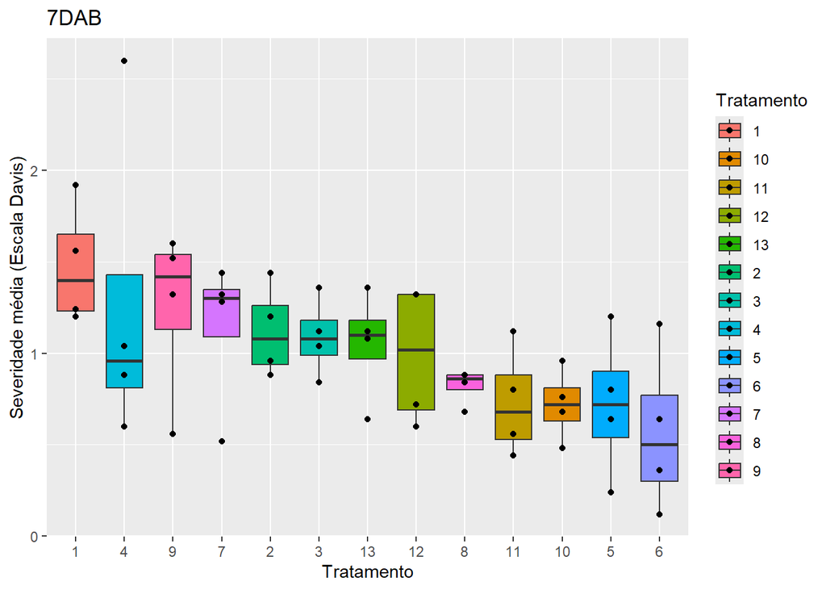